# Analyze Collinsella

Yixuan Yang

# Set Up

```r
rm(list = ls())
set.seed(2024)
library(tidyverse)
library(here)
library(rstatix)
library(phyloseq)
library(gt)
library(broom)
theme_set(theme_bw())

ps.rare <- readRDS(here('data','following_study','ps_rarefied.rds'))
```

# Collinsella

In DA analyses section, we found one `Collinsella` ASV that was consistently identified differentially abundant by all DA methods.

## Differential Abundance

The log2 fold difference in relative abundance between IE and control dogs from the same household for the five most abundant Collinsella ASVs and total Collinsella. Absent bars indicate that the Collinsella ASV was not detected in either dog in that household.

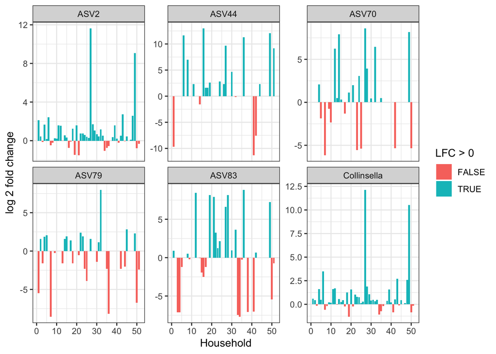

```r
ps.collinsella <- ps.rare %>%
    subset_taxa(Genus == 'Collinsella')
genus.collinsella <- ps.collinsella %>%
    tax_glom('Genus') %>%
    otu_table() %>% data.frame() %>%
    rename(Collinsella = ASV2)

# add genus level collinsella count to otu table
collinsella.df <- ps.collinsella %>%
    filter_taxa(function(x) sum(x>0)/length(x)>=0.1, prune = TRUE) %>%  # filter out taxa with prevalence lower than 10%
    otu_table() %>%
    cbind(genus.collinsella) %>%
    cbind(data.frame(sample_data(ps.collinsella))) %>%
    pivot_longer(c(starts_with('ASV'), 'Collinsella'), names_to = 'ASV', values_to = 'Abundance')


lfc <- collinsella.df %>%
    group_by(Household, ASV) %>%
    summarise(LFC = log2(Abundance[Epileptic.or.Control == "Epileptic"] + 0.5) -
                  log2(Abundance[Epileptic.or.Control == "Control"] + 0.5),
              .groups = 'drop')

ggplot(lfc) +
    geom_bar(aes(x = as.numeric(Household), y = LFC, fill = (LFC > 0)), stat = 'identity') +
    facet_wrap(~ASV, scales = 'free_y') +
    labs(x = 'Household', y = 'log 2 fold change', fill = 'LFC > 0')
```

```r
ggsave(here('figures','Figure5.png'))
ggsave(here('figures','Figure5.pdf'))
```

We can visually see some ASVs are more abunant in IE group. Here, we use pairwise sign test to check.

```r
collinsella.df %>%
    group_by(ASV) %>%
    arrange(Household) %>% # make sure data are paired
    pairwise_sign_test(Abundance ~ Epileptic.or.Control, ref.group = 'Epileptic', alternative = 'greater', paired = TRUE) %>% gt
```

| ASV | .y. | group1 | group2 | n1 | n2 | statistic | df | p | p.adj | p.adj.signif |
| --- | --- | --- | --- | --- | --- | --- | --- | --- | --- | --- |
| ASV2 | Abundance | Epileptic | Control | 49 | 49 | 34 | 49 | 0.005 | 0.005 | ** |
| ASV44 | Abundance | Epileptic | Control | 49 | 49 | 15 | 20 | 0.021 | 0.021 | * |
| ASV70 | Abundance | Epileptic | Control | 49 | 49 | 14 | 23 | 0.202 | 0.202 | ns |
| ASV79 | Abundance | Epileptic | Control | 49 | 49 | 13 | 29 | 0.771 | 0.771 | ns |
| ASV83 | Abundance | Epileptic | Control | 49 | 49 | 15 | 30 | 0.572 | 0.572 | ns |
| Collinsella | Abundance | Epileptic | Control | 49 | 49 | 35 | 49 | 0.002 | 0.002 | ** |

ASV2, ASV44 and the total Collinsella are significantly more abundant in IE dogs.

## Chi-Square test

Association between sex and the presence of Collinsella can have a confounding effect

```r
ftable(xtabs( ~ Sex  + sign(Abundance) + ASV, data = collinsella.df))
```

```
##                     ASV ASV2 ASV44 ASV70 ASV79 ASV83 Collinsella
## Sex sign(Abundance)
## F   0                      1    45    34    25    29           1
##     1                     57    13    24    33    29          57
## M   0                      0    26    28    28    23           0
##     1                     40    14    12    12    17          40
```

```r
collinsella.df %>%
    split(.$ASV) %>%
    map_dfr(function(df) tidy(chisq.test(xtabs( ~ Sex  + sign(Abundance), data = df))), .id = 'ASV') %>%
    gt %>% fmt_number(decimals = 3)
```

| ASV | statistic | p.value | parameter | method |
| --- | --- | --- | --- | --- |
| ASV2 | 0.000 | 1.000 | 1.000 | Pearson's Chi-squared test with Yates' continuity correction |
| ASV44 | 1.301 | 0.254 | 1.000 | Pearson's Chi-squared test with Yates' continuity correction |
| ASV70 | 0.875 | 0.350 | 1.000 | Pearson's Chi-squared test with Yates' continuity correction |
| ASV79 | 5.856 | 0.016 | 1.000 | Pearson's Chi-squared test with Yates' continuity correction |
| ASV83 | 0.276 | 0.599 | 1.000 | Pearson's Chi-squared test with Yates' continuity correction |
| Collinsella | 0.000 | 1.000 | 1.000 | Pearson's Chi-squared test with Yates' continuity correction |

Presence of ASV79 is associated with sex.

## Abundance Change Across other factors

### Age

Does the abundance of Collinsella different by age?

```r
collinsella.df %>%
    split(.$ASV) %>%
    map_dfr(function(df) tidy(lm(Abundance ~ Age..months., data = df)), .id = 'ASV') %>%
    group_by(ASV) %>% gt %>% fmt_number(decimals = 3)
```

| term | estimate | std.error | statistic | p.value |
| --- | --- | --- | --- | --- |
| ASV2 |  |  |  |  |
| (Intercept) | 3,893.154 | 591.636 | 6.580 | 0.000 |
| Age..months. | −0.771 | 7.078 | −0.109 | 0.913 |
| ASV44 |  |  |  |  |
| (Intercept) | 4.294 | 187.426 | 0.023 | 0.982 |
| Age..months. | 2.921 | 2.242 | 1.303 | 0.196 |
| ASV70 |  |  |  |  |
| (Intercept) | −34.719 | 51.240 | −0.678 | 0.500 |
| Age..months. | 1.400 | 0.613 | 2.284 | 0.025 |
| ASV79 |  |  |  |  |
| (Intercept) | 19.143 | 60.824 | 0.315 | 0.754 |
| Age..months. | 0.748 | 0.728 | 1.028 | 0.307 |
| ASV83 |  |  |  |  |
| (Intercept) | −0.162 | 19.133 | −0.008 | 0.993 |
| Age..months. | 0.726 | 0.229 | 3.172 | 0.002 |
| Collinsella |  |  |  |  |
| (Intercept) | 3,927.815 | 586.870 | 6.693 | 0.000 |
| Age..months. | 4.794 | 7.021 | 0.683 | 0.496 |

The abundance of ASV83 was significantly higher in older dogs.

### Seizure Freedom/Seizure Control

Does the abundance of Collinsella change by seizure freedom or seizure controlled dogs?

```r
collinsella.df %>%
    filter(Epileptic.or.Control == 'Epileptic') %>%
    split(.$ASV) %>%
    map_dfr(function(df) tidy(t.test(Abundance ~ Seizure.Freedom..Y.N., data = df)), .id = 'ASV') %>%
    gt %>% fmt_number(decimals = 3)
```

| ASV | estimate | estimate1 | estimate2 | statistic | p.value | parameter | conf.low | conf.high | method | alternative |
| --- | --- | --- | --- | --- | --- | --- | --- | --- | --- | --- |
| ASV2 | −296.688 | 4,176.125 | 4,472.812 | −0.390 | 0.699 | 31.314 | −1,849.271 | 1,255.896 | Welch Two Sample t-test | two.sided |
| ASV44 | −180.312 | 268.812 | 449.125 | −0.517 | 0.611 | 22.078 | −904.025 | 543.400 | Welch Two Sample t-test | two.sided |
| ASV70 | 69.656 | 114.031 | 44.375 | 1.118 | 0.271 | 36.866 | −56.637 | 195.950 | Welch Two Sample t-test | two.sided |
| ASV79 | −185.094 | 20.719 | 205.812 | −1.385 | 0.186 | 15.093 | −469.799 | 99.612 | Welch Two Sample t-test | two.sided |
| ASV83 | −40.688 | 48.812 | 89.500 | −1.210 | 0.240 | 20.213 | −110.781 | 29.406 | Welch Two Sample t-test | two.sided |
| Collinsella | −641.688 | 4,652.375 | 5,294.062 | −0.832 | 0.413 | 27.717 | −2,222.698 | 939.323 | Welch Two Sample t-test | two.sided |

```r
collinsella.df %>%
    filter(Epileptic.or.Control == 'Epileptic') %>%
    split(.$ASV) %>%
    map_dfr(function(df) tidy(t.test(Abundance ~ Seizure.Control..Satisfactory.Unsatisfactory., data = df)), .id = 'ASV') %>%
    gt %>% fmt_number(decimals = 3)
```

| ASV | estimate | estimate1 | estimate2 | statistic | p.value | parameter | conf.low | conf.high | method | alternative |
| --- | --- | --- | --- | --- | --- | --- | --- | --- | --- | --- |
| ASV2 | 154.789 | 4,316.943 | 4,162.154 | 0.178 | 0.860 | 19.465 | −1,658.623 | 1,968.201 | Welch Two Sample t-test | two.sided |
| ASV44 | −149.389 | 288.457 | 437.846 | −0.420 | 0.679 | 18.537 | −894.329 | 595.551 | Welch Two Sample t-test | two.sided |
| ASV70 | −92.354 | 65.800 | 158.154 | −0.673 | 0.513 | 12.794 | −389.207 | 204.500 | Welch Two Sample t-test | two.sided |
| ASV79 | 98.681 | 109.143 | 10.462 | 1.581 | 0.123 | 34.555 | −28.061 | 225.424 | Welch Two Sample t-test | two.sided |
| ASV83 | 28.892 | 70.200 | 41.308 | 1.130 | 0.267 | 31.857 | −23.203 | 80.987 | Welch Two Sample t-test | two.sided |
| Collinsella | 71.791 | 4,885.714 | 4,813.923 | 0.087 | 0.932 | 20.149 | −1,654.774 | 1,798.356 | Welch Two Sample t-test | two.sided |

none of the Collinsella ASV were found to be significantly differentially abundant between seizure free or seizure controlled dogs.

# Lactobacillus

Lactobacillus has attracted growing attention for its potential beneficial role in epilepsy.

## Differential Abundance

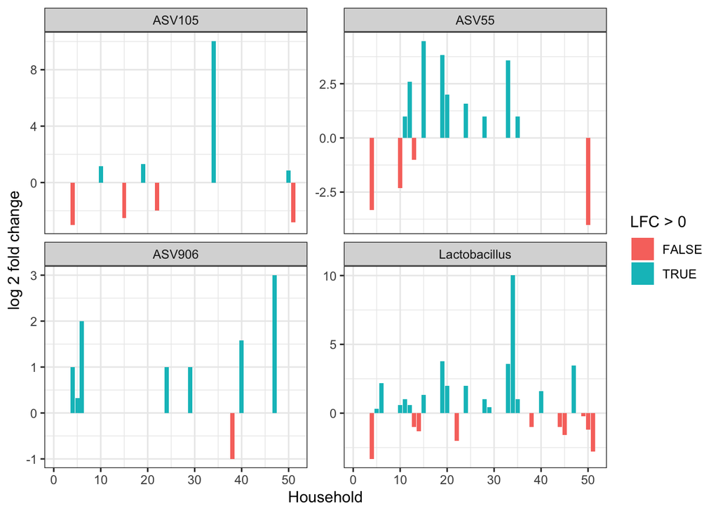

```r
ps.lactobacillus <- ps.rare %>%
    subset_taxa(Genus == 'Lactobacillus')
genus.lactobacillus <- ps.lactobacillus %>%
    tax_glom('Genus') %>%
    otu_table() %>% data.frame() %>%
    rename(Lactobacillus = ASV55)

# add genus level lactobacillus count to otu table
lactobacillus.df <- ps.lactobacillus %>%
    filter_taxa(function(x) sum(x>0)/length(x)>=0.1, prune = TRUE) %>%  # filter out taxa with prevalence lower than 10%
    otu_table() %>%
    cbind(genus.lactobacillus) %>%
    cbind(data.frame(sample_data(ps.lactobacillus))) %>%
    pivot_longer(c(starts_with('ASV'), 'Lactobacillus'), names_to = 'ASV', values_to = 'Abundance')


lfc <- lactobacillus.df %>%
    group_by(Household, ASV) %>%
    summarise(LFC = log2(Abundance[Epileptic.or.Control == "Epileptic"] + 1) -
                  log2(Abundance[Epileptic.or.Control == "Control"] + 1),
              .groups = 'drop')

ggplot(lfc) +
    geom_bar(aes(x = as.numeric(Household), y = LFC, fill = (LFC > 0)), stat = 'identity') +
    facet_wrap(~ASV, scales = 'free_y') +
    labs(x = 'Household', y = 'log 2 fold change', fill = 'LFC > 0')
```

```r
lactobacillus.df  %>%
    group_by(ASV) %>%
    arrange(Household) %>% # make sure data are paired
    pairwise_sign_test(Abundance ~ Epileptic.or.Control, ref.group = 'Epileptic', alternative = 'greater', paired = TRUE) %>% gt
```

| ASV | .y. | group1 | group2 | n1 | n2 | statistic | df | p | p.adj | p.adj.signif |
| --- | --- | --- | --- | --- | --- | --- | --- | --- | --- | --- |
| ASV105 | Abundance | Epileptic | Control | 49 | 49 | 4 | 8 | 0.637 | 0.637 | ns |
| ASV55 | Abundance | Epileptic | Control | 49 | 49 | 9 | 13 | 0.133 | 0.133 | ns |
| ASV906 | Abundance | Epileptic | Control | 49 | 49 | 7 | 8 | 0.035 | 0.035 | * |
| Lactobacillus | Abundance | Epileptic | Control | 49 | 49 | 16 | 26 | 0.163 | 0.163 | ns |

ASV906 is significantly more abundant in epileptic dogs

## Chi-Square Test

Does the presense of Lactobacillus associated with sex?

```r
ftable(xtabs(sign(Abundance) ~ Sex + Epileptic.or.Control + ASV, data = lactobacillus.df))
```

```
##                          ASV ASV105 ASV55 ASV906 Lactobacillus
## Sex Epileptic.or.Control
## F   Control                       5     4      4            13
##     Epileptic                     2     5      6            12
## M   Control                       2     2      0             5
##     Epileptic                     3     6      1             8
```

```r
lactobacillus.df %>%
    split(.$ASV) %>%
    map_dfr(function(df) tidy(chisq.test(xtabs( ~ Sex  + sign(Abundance), data = df))), .id = 'ASV') %>%
    gt %>% fmt_number(decimals = 3)
```

| ASV | statistic | p.value | parameter | method |
| --- | --- | --- | --- | --- |
| ASV105 | 0.000 | 1.000 | 1.000 | Pearson's Chi-squared test with Yates' continuity correction |
| ASV55 | 0.093 | 0.761 | 1.000 | Pearson's Chi-squared test with Yates' continuity correction |
| ASV906 | 3.789 | 0.052 | 1.000 | Pearson's Chi-squared test with Yates' continuity correction |
| Lactobacillus | 0.719 | 0.396 | 1.000 | Pearson's Chi-squared test with Yates' continuity correction |

ASV906 is marginally significant

## Abundance Change

### Age

Does the abundance change by age?

```r
lactobacillus.df %>%
    split(.$ASV) %>%
    map_dfr(function(df) tidy(lm(Abundance ~ Age..months., data = df)), .id = 'ASV') %>%
    group_by(ASV) %>% gt %>% fmt_number(decimals = 3)
```

| term | estimate | std.error | statistic | p.value |
| --- | --- | --- | --- | --- |
| ASV105 |  |  |  |  |
| (Intercept) | −26.663 | 60.499 | −0.441 | 0.660 |
| Age..months. | 0.905 | 0.724 | 1.250 | 0.214 |
| ASV55 |  |  |  |  |
| (Intercept) | −329.842 | 173.680 | −1.899 | 0.061 |
| Age..months. | 5.587 | 2.078 | 2.689 | 0.008 |
| ASV906 |  |  |  |  |
| (Intercept) | 0.338 | 0.291 | 1.162 | 0.248 |
| Age..months. | 0.000 | 0.003 | −0.043 | 0.966 |
| Lactobacillus |  |  |  |  |
| (Intercept) | −357.026 | 196.484 | −1.817 | 0.072 |
| Age..months. | 6.574 | 2.351 | 2.797 | 0.006 |

## Seizure Free / Seizure Control

Does abundance change by these groups?

```r
lactobacillus.df %>%
    filter(Epileptic.or.Control == 'Epileptic') %>%
    split(.$ASV) %>%
    map_dfr(function(df) tidy(t.test(Abundance ~ Seizure.Freedom..Y.N., data = df)), .id = 'ASV') %>%
    gt %>% fmt_number(decimals = 3)
```

| ASV | estimate | estimate1 | estimate2 | statistic | p.value | parameter | conf.low | conf.high | method | alternative |
| --- | --- | --- | --- | --- | --- | --- | --- | --- | --- | --- |
| ASV105 | 52.156 | 52.406 | 0.250 | 1.491 | 0.146 | 31.003 | −19.166 | 123.479 | Welch Two Sample t-test | two.sided |
| ASV55 | 215.719 | 233.594 | 17.875 | 0.927 | 0.361 | 31.233 | −258.556 | 689.994 | Welch Two Sample t-test | two.sided |
| ASV906 | −1.062 | 0.188 | 1.250 | −1.671 | 0.113 | 17.014 | −2.404 | 0.279 | Welch Two Sample t-test | two.sided |
| Lactobacillus | 266.438 | 286.375 | 19.938 | 1.083 | 0.287 | 31.212 | −235.323 | 768.198 | Welch Two Sample t-test | two.sided |

```r
lactobacillus.df %>%
    filter(Epileptic.or.Control == 'Epileptic') %>%
    split(.$ASV) %>%
    map_dfr(function(df) tidy(t.test(Abundance ~ Seizure.Control..Satisfactory.Unsatisfactory., data = df)), .id = 'ASV') %>%
    gt %>% fmt_number(decimals = 3)
```

| ASV | estimate | estimate1 | estimate2 | statistic | p.value | parameter | conf.low | conf.high | method | alternative |
| --- | --- | --- | --- | --- | --- | --- | --- | --- | --- | --- |
| ASV105 | 47.185 | 47.800 | 0.615 | 1.473 | 0.150 | 34.025 | −17.921 | 112.291 | Welch Two Sample t-test | two.sided |
| ASV55 | 221.321 | 221.629 | 0.308 | 1.043 | 0.304 | 34.000 | −209.805 | 652.447 | Welch Two Sample t-test | two.sided |
| ASV906 | 0.637 | 0.714 | 0.077 | 1.927 | 0.062 | 37.651 | −0.032 | 1.307 | Welch Two Sample t-test | two.sided |
| Lactobacillus | 269.044 | 270.429 | 1.385 | 1.198 | 0.239 | 34.001 | −187.249 | 725.337 | Welch Two Sample t-test | two.sided |

# More Information

## Prevalence

```r
prev <- ps.rare %>%
    filter_taxa(function(x) sum(x>0)/length(x)>=0.1, prune = TRUE) %>%
    psmelt() %>%
    filter(Genus %in% c('Collinsella', 'Lactobacillus')) %>%
    group_by(OTU, Genus) %>%
    summarise(Frequency = sum(Abundance > 0),
              Prevalence = sum(Abundance > 0) / n()) %>%
    arrange(Genus)
```

[output not shown]

```r
prev
```

```
## # A tibble: 8 × 4
## # Groups:   OTU [8]
##   OTU    Genus         Frequency Prevalence
##   <chr>  <chr>             <int>      <dbl>
## 1 ASV2   Collinsella          97      0.990
## 2 ASV44  Collinsella          27      0.276
## 3 ASV70  Collinsella          36      0.367
## 4 ASV79  Collinsella          45      0.459
## 5 ASV83  Collinsella          46      0.469
## 6 ASV105 Lactobacillus        12      0.122
## 7 ASV55  Lactobacillus        17      0.173
## 8 ASV906 Lactobacillus        11      0.112
```

```r
ps.rare %>%
    tax_glom('Genus') %>%
    psmelt() %>%
    filter(Genus %in% c('Collinsella', 'Lactobacillus')) %>%
    group_by(OTU, Genus) %>%
    summarise(Frequency = sum(Abundance > 0),
              Prevalence = sum(Abundance > 0) / n()) %>%
    arrange(Genus)
```

[output not shown]

```
## # A tibble: 2 × 4
## # Groups:   OTU [2]
##   OTU   Genus         Frequency Prevalence
##   <chr> <chr>             <int>      <dbl>
## 1 ASV2  Collinsella          97      0.990
## 2 ASV55 Lactobacillus        38      0.388
```

## Taxonomy

```r
tax_table(ps.rare)[prev$OTU, c('Genus','Species')]
```

```
## Taxonomy Table:     [8 taxa by 2 taxonomic ranks]:
##        Genus           Species
## ASV2   "Collinsella"   NA
## ASV44  "Collinsella"   "aerofaciens"
## ASV70  "Collinsella"   "tanakaei"
## ASV79  "Collinsella"   NA
## ASV83  "Collinsella"   "phocaeensis"
## ASV105 "Lactobacillus" NA
## ASV55  "Lactobacillus" NA
## ASV906 "Lactobacillus" NA
```

Some of the species were not identified. We can use blast to search against the nt/nr database and get their percentage identity.

```r
# extract sequence of these ASVs
refseq(ps.rare)[prev$OTU] %>% dada2:::pfasta(ids = prev$OTU)
```

```
## >ASV2
## TACGTAGGGGGCGAGCGTTATCCGGATTCATTGGGCGTAAAGCGCGCGTAGGCGGCCCGG…
## >ASV44
## TACGTAGGGGGCGAGCGTTATCCGGATTCATTGGGCGTAAAGCGCGCGTAGGCGGCCCGG…
## >ASV70
## TACGTAGGGGGCGAGCGTTATCCGGATTCATTGGGCGTAAAGCGCGCGTAGGCGGCCGCG…
## >ASV79
## TACGTAGGGGGCGAGCGTTATCCGGATTCATTGGGCGTAAAGCGCGCGTAGGCGGCCGCG…
## >ASV83
## TACGTAGGGGGCGAGCGTTATCCGGATTCATTGGGCGTAAAGCGCGCGTAGGCGGCCCGG…
## >ASV105
## TACGTAGGTGGCAAGCGTTGTCCGGATTTATTGGGCGTAAAGCGAGTGCAGGCGGTTCAA…
## >ASV55
## TACGTAGGTGGCAAGCGTTGTCCGGATTTATTGGGCGTAAAGCGAGCGCAGGCGGAAGAA…
## >ASV906
## TACGTAGGTGGCAAGCGTTGTCCGGATTTATTGGGCGTAAAGCGAGCGCAGGCGGAAAAA…
```

Here’s the result:

| taxon | species | identity |
| --- | --- | --- |
| ASV2 | Collinsella stercoris | 100% |
| ASV44 | Collinsella aerofaciens | 100% |
| ASV70 | Collinsella tanakaei | 100% |
| ASV79 | Collinsella tanakaei | 98.81% |
| ASV83 | Collinsella phocaeensis | 100% |
| ASV105 | Lactobacillus gasseri | 100% |
| ASV55 | Lactobacillus crispatus | 100% |
| ASV906 | Lactobacillus amylovorus | 100% |